# Lab 8

Vickie Bach

3/8/26

## Lab 8: Practicing Tidyverse and assessing environmental inequities in the US

In this lab I am giving you a dataset created by merging county-level racial and income data from the Census Bureau (which I obtained using the tidycensus package - useful if you want to use census data in your final project) with data on environmental pollution from EPA’s [EJSCREEN]https://www.epa.gov/ejscreen dataset to investigate the associate between race, class, and environmental exposure in the US.

The variable definitions are as follows: GEOID: Unique county identifier NAME: County Name pct_AfAm: Percent population African American pct_low_income: Percent low income (household income <$25,000) DSLPM: Diesel Particulate Matter CANCER: Cancer Risk Measure RESP: Respiratory Hazard Index PNPL: Superfund Proximity OZONE: Ozone Concentration Score PM25: PM 2.5 Concentration Score

Wherever possible, pracitce using Tidyverse syntax and functions

Read in the dataset lab8data_censusandEJscreen.csv

```r
library (tidyverse)
lab8 <- read_csv("~/R/Lab 8/lab8data_censusandEJscreen.csv")
```

```
## ──────────────────────────────────────────────────────── Delimiter: "," chr
## (1): NAME dbl (12): ...1, GEOID, STATE, pct_AfAm, pct_low_inc, X, DSLPM,
## CANCER, RESP,...
```

1. The goal of this lab is to assess how race, income, and exposure to environmental pollution vary across counties. This is challenging right now because the pollution and social variables are on very different scales. We will fix this by transforming all relevant variables to their quintile group (i.e. is a particular county in the bottom fifth, second from bottom fifth etc) before doing our analysis.

Write a function that takes in a vector and returns the quintile group for each element in the vector.

Hint: you will want to use quantile() to find the breaks for each quintile group. The relevant probabilities will be c(0,0.2,0.4,0.6,0.8) - i.e. 20%, 40%, 60% etc. You can then use these quantiles in the findInterval() function to find which group each county falls into

```r
quintile_fun <- function(x){
  breaks <- quantile(x,
                     probs = c (0,0.2,0.4,0.6,0.8),
                     na.rm = TRUE)
  findInterval(x,breaks)
}
```

2. Use mutate() to apply your quintile function to the two socio-economic variables (% African American and % low income) and the six environmental variables.

HINT: specifying across(c(columnnames),function) within mutate allows you to apply the same function to multiple columns

```r
lab8_q <- lab8 %>%
  mutate(across(c(pct_AfAm, pct_low_inc,
         DSLPM, CANCER, RESP, PNPL, OZONE, PM25),
quintile_fun))
```

3. Now we will make a plot examining how exposure to pollution varies with race. I have provided this plot as part of the lab materials (Plot 1). For each quintile of African American population (x axis) it plots the mean quintile of environmental exposure, for each pollutant, with the central 95% of the distribution in each race quintile.

3.1 First we need to some data wrangling to get things in a format for the plot.

Use tidyverse operations to: - select the relevant columns we need: county ID and quintile of African American popualation, low-income, and the 6 pollution variables - use pivot_longer() to transform the data frame from one where each row is a county to one where each row is a county * pollution combination. In other words, the cols argument of pivot_longer() will be the 6 pollution variables - use group_by() and summarize() to calcuate the mean and standard deviation of environmental exposure for each pollutant and quintile of African American population

```r
plot_data <- lab8_q %>%
  select(GEOID, pct_AfAm, pct_low_inc,
         DSLPM, CANCER, RESP, PNPL, OZONE, PM25) %>%
  pivot_longer(cols = c(DSLPM, CANCER, RESP, PNPL,
                        OZONE, PM25),
               names_to = "pollutant",
               values_to = "exposure") %>%
  group_by(pct_AfAm, pollutant) %>%
  summarize(mean_exposure = mean(exposure,
                                 na.rm = TRUE),
            sd_exposure = sd (exposure,
                              na.rm = TRUE),
            .groups = "drop")
```

3.2 Now we will use this data frame to make the plot. You will want to use geom_point(), geom_errorbar(), and facet_wrap() here.

HINT: geom_errorbar() requires a ymin and ymax aesthetic mapping. Remember that, assuming normal distribution, the central 95% of the distribution is given by ymin = mean - 1.96 X sd and ymax = mean + 1.96 X sd

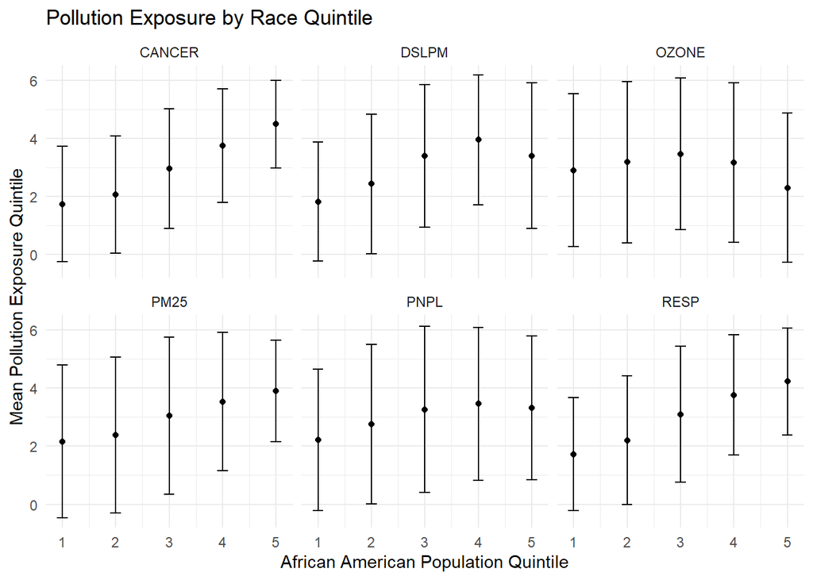

```r
ggplot(plot_data,
       aes(x = pct_AfAm,
           y = mean_exposure)) +
  geom_point() +
  geom_errorbar(aes(ymin = mean_exposure - 1.96*sd_exposure,
                    ymax = mean_exposure + 1.96*sd_exposure),
                width = 0.2) +
  facet_wrap(~ pollutant) +
  labs(x = "African American Population Quintile",
       y = "Mean Pollution Exposure Quintile",
       title = "Pollution Exposure by Race Quintile") +
  theme_minimal ()
```

3.3 Now make a very similar plot, but examine variation in environmental expsure by both race and income (Plot2 on Canvas).

HINT: You should have to make only *very very minor* changes to the code you used for part 7.1 and 7.2 (this is part of the benefits of coding using tidyverse).

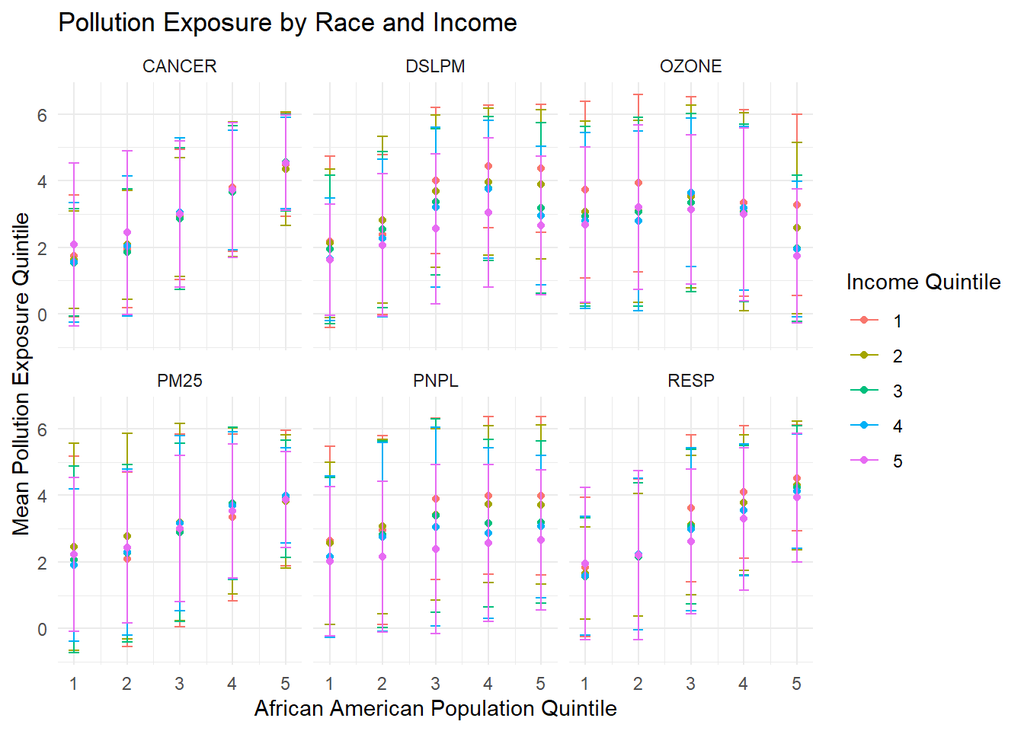

```r
plot_data2 <- lab8_q %>%
  select(GEOID, pct_AfAm, pct_low_inc,
         DSLPM, CANCER, RESP, PNPL, OZONE, PM25) %>%
  pivot_longer(cols = c(DSLPM, CANCER, RESP,
                         PNPL, OZONE, PM25),
                names_to = "pollutant",
                values_to = "exposure") %>%
  group_by(pct_AfAm, pct_low_inc, pollutant) %>%
  summarize(mean_exposure = mean(exposure, na.rm = TRUE),
            sd_exposure = sd(exposure, na.rm = TRUE),
            .groups = "drop")

ggplot(plot_data2,
       aes(x = pct_AfAm,
           y = mean_exposure,
           color = factor(pct_low_inc))) +

  geom_point() +

  geom_errorbar(aes(ymin = mean_exposure - 1.96*sd_exposure,
                    ymax = mean_exposure + 1.96*sd_exposure),
                width = 0.2) +

  facet_wrap(~ pollutant) +

  labs(x = "African American Population Quintile",
       y = "Mean Pollution Exposure Quintile",
       color = "Income Quintile",
       title = "Pollution Exposure by Race and Income") +

  theme_minimal()
```

3. What preliminary conclusions might you draw from this exploratory data analysis about the correlation between race, class and environmental exposure acrosso the US?

STRETCH GOAL: Not for credit, but if you want to challenge yourself to use nesting, tidyr, broom, map etc.

1. Use nest, map, and tidy to estimate state-level regression models of the cancer risk quintile on race and class quintile and collect the regression estimates into a data frame
2. Plot the race and class coefficients with 95% confidence intervals, using colors to show coefficients that are statistically significant at the 95% level (Plot3 on Canvas)